# IODS course project

### Aggregate summary graphs

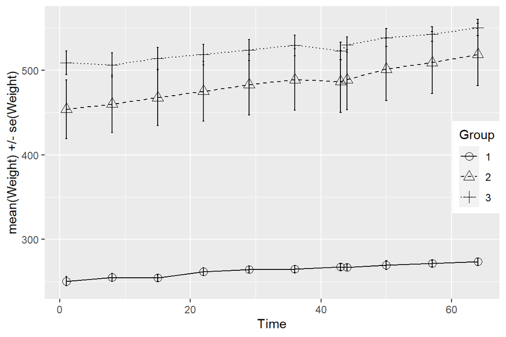

```r
library(plotrix)
RATS <- RATS %>%
  group_by(Group, Time) %>%
  summarise( mean = mean(Weight), se = std.error(Weight)) %>%
  ungroup()
# Plot the mean profiles
library(ggplot2)
ggplot(RATS, aes(x = Time, y = mean, linetype = Group, shape = Group)) +
  geom_line() +
  scale_linetype_manual(values = c(1,2,3)) +
  geom_point(size=3) +
  scale_shape_manual(values = c(1,2,3)) +
  geom_errorbar(aes(ymin=mean-se, ymax=mean+se, linetype="1"), width=0.3) +
  theme(legend.position = c(0.95,0.45)) +
  scale_y_continuous(name = "mean(Weight) +/- se(Weight)")
```

### Boxplot summary of rat groups mean weights

```r
RATS<-read.csv(here("C:\\LocalData\\navarret\\IODS\\IODS-project\\data\\rats_lng.csv"))
RATS$X<-NULL
RATS$ID<-as.factor(RATS$ID)
RATS$Group<-as.factor(RATS$Group)

Rats_mean <- RATS %>%
  group_by(Time, Group) %>%
  summarise( mean=mean(Weight) ) %>%
  ungroup()
```

[output not shown]

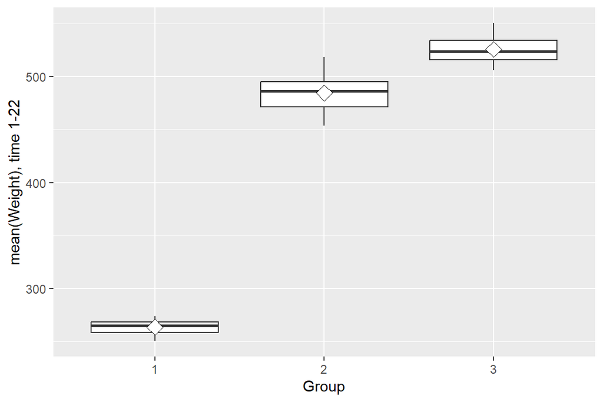

```r
library(ggplot2)
ggplot(Rats_mean, aes(x = Group, y = mean)) +
  geom_boxplot() +
  stat_summary(fun = "mean", geom = "point", shape=23, size=4, fill = "white") +
  scale_y_continuous(name = "mean(Weight), time 1-22")
```

Once again, Group 1 stands out, engaging in its unique dynamics characterized by a notably lower mean weight and reduced variability compared to the other groups. Group 2 displays the highest variance in weights within its members, showcasing a diverse range of individual variations. On the other hand, Group 3 boasts the overall highest mean weight, distinguishing itself in this aspect. Notably, there are no identifiable outliers in any of the groups, underscoring the consistency and reliability of the observed weight patterns.

### Statistical Testing

Given the existence of three distinct groups of rats, the conventional 2-sample t test is not a viable tool, as it is designed to accommodate only two groups. Consequently, we are compelled to proceed directly to an analysis of variance (ANOVA) to appropriately assess and compare the variations among the multiple groups.

```r
# Fit the linear model with the mean as the response
fit <- lm(mean ~ Group, data = Rats_mean)
anova(fit)
```

```
## Analysis of Variance Table
##
## Response: mean
##           Df Sum Sq Mean Sq F value    Pr(>F)
## Group      2 437104  218552  1006.3 < 2.2e-16 ***
## Residuals 30   6516     217
## ---
## Signif. codes:  0 '***' 0.001 '**' 0.01 '*' 0.05 '.' 0.1 ' ' 1
```

```r
Rats_mean_filtered<-filter(Rats_mean, Group %in% c(2,3))
# Fit the linear model with the mean as the response
fit <- lm(mean ~ Group, data = Rats_mean_filtered)
anova(fit)
```

```
## Analysis of Variance Table
##
## Response: mean
##           Df Sum Sq Mean Sq F value    Pr(>F)
## Group      1 9286.5  9286.5  31.192 1.819e-05 ***
## Residuals 20 5954.5   297.7
## ---
## Signif. codes:  0 '***' 0.001 '**' 0.01 '*' 0.05 '.' 0.1 ' ' 1
```

## Task 2

In this task, we will implement the analyses of Chapter 9 of MABS, using the R codes of Exercise Set 6, but using the BPRS data.

### Loading data

```r
library(readr)
library(here)
BPRS_lng <- read_csv(here("C://LocalData//navarret//IODS//IODS-project//data//BPRS_lng.csv"))
BPRS_lng$...1<-NULL

#Re-factorize the treatment var
BPRS_lng$treatment<-as.factor(BPRS_lng$treatment)
```

### Statistical analysis

Initially, we apply a random intercept model to the BPRS data. Diverging from the standard linear regressions performed with the lm-function, this model accommodates the uniqueness of each test subject by allowing for different regression slope intercept points. Importantly, it deviates from assuming independence among observations, especially pertinent when dealing with data collected from the same patients over time.

Our primary objective is to elucidate the PBRS score, with treatment group and time as key explanatory factors. Here, we designate Subject ID as the random effect, recognizing the variability from one individual to another. Both treatment and time are treated as fixed effects, providing a comprehensive framework for capturing the nuanced dynamics within the dataset.

```r
library(lme4)
BPRS_RandomInt <- lmer(pbrs ~ Week + treatment + (1 | subject), data = BPRS_lng, REML = FALSE)
summary(BPRS_RandomInt)
```

```
## Linear mixed model fit by maximum likelihood  ['lmerMod']
## Formula: pbrs ~ Week + treatment + (1 | subject)
##    Data: BPRS_lng
##
##      AIC      BIC   logLik deviance df.resid
##   2748.7   2768.1  -1369.4   2738.7      355
##
## Scaled residuals:
##     Min      1Q  Median      3Q     Max
## -3.0481 -0.6749 -0.1361  0.4813  3.4855
##
## Random effects:
##  Groups   Name        Variance Std.Dev.
##  subject  (Intercept)  47.41    6.885
##  Residual             104.21   10.208
## Number of obs: 360, groups:  subject, 20
##
## Fixed effects:
##             Estimate Std. Error t value
## (Intercept)  46.4539     1.9090  24.334
## Week         -2.2704     0.2084 -10.896
## treatment2    0.5722     1.0761   0.532
##
## Correlation of Fixed Effects:
##            (Intr) Week
## Week       -0.437
## treatment2 -0.282  0.000
```

```r
anova(BPRS_RandomInt)
```

```
## Analysis of Variance Table
##           npar  Sum Sq Mean Sq  F value
## Week         1 12371.5 12371.5 118.7136
## treatment    1    29.5    29.5   0.2828
```

To gauge the model’s overall fit, we turn to the Akaike Information Criteria (AIC), a valuable tool for model comparison. With a current AIC of 2748, we have a metric for assessing relative model performance – lower AIC values suggest a better fit to the data.

In this nuanced analysis, we deploy a model featuring both random intercepts and random slopes, providing a comprehensive framework that accounts for both individual variability and the dynamic relationships among the variables.

```r
library(lme4)

BPRS_int_coeff<-lmer(pbrs ~ Week + treatment + (Week | subject), data = BPRS_lng, REML = FALSE)

# print a summary of the model
summary(BPRS_int_coeff)
```

```
## Linear mixed model fit by maximum likelihood  ['lmerMod']
## Formula: pbrs ~ Week + treatment + (Week | subject)
##    Data: BPRS_lng
##
##      AIC      BIC   logLik deviance df.resid
##   2745.4   2772.6  -1365.7   2731.4      353
##
## Scaled residuals:
##     Min      1Q  Median      3Q     Max
## -2.8919 -0.6194 -0.0691  0.5531  3.7976
##
## Random effects:
##  Groups   Name        Variance Std.Dev. Corr
##  subject  (Intercept) 64.8222  8.0512
##           Week         0.9609  0.9802   -0.51
##  Residual             97.4305  9.8707
## Number of obs: 360, groups:  subject, 20
##
## Fixed effects:
##             Estimate Std. Error t value
## (Intercept)  46.4539     2.1052  22.066
## Week         -2.2704     0.2977  -7.626
## treatment2    0.5722     1.0405   0.550
##
## Correlation of Fixed Effects:
##            (Intr) Week
## Week       -0.582
## treatment2 -0.247  0.000
```

```r
# perform an ANOVA test on the two models
anova(BPRS_int_coeff)
```

```
## Analysis of Variance Table
##           npar Sum Sq Mean Sq F value
## Week         1 5666.0  5666.0 58.1540
## treatment    1   29.5    29.5  0.3025
```

With an improved fit evidenced by a decreased AIC to 2745, our model now outperforms its predecessor, which only allowed intercepts to vary among individuals. The random effects display a significant increase in variance, emphasizing substantial between-individual variation in both intercepts and slopes.

Now we introduce an interaction variable (week x treatment) for a more nuanced analysis. This addition enhances the model’s capacity to capture intricate dynamics between time and treatment, contributing to a richer understanding of the data.

```r
library(lme4)

Interaction<-lmer(pbrs ~ Week + treatment + (Week | subject)+Week*treatment, data = BPRS_lng, REML = FALSE)

# print a summary of the model
summary(Interaction)
```

```
## Linear mixed model fit by maximum likelihood  ['lmerMod']
## Formula: pbrs ~ Week + treatment + (Week | subject) + Week * treatment
##    Data: BPRS_lng
##
##      AIC      BIC   logLik deviance df.resid
##   2744.3   2775.4  -1364.1   2728.3      352
##
## Scaled residuals:
##     Min      1Q  Median      3Q     Max
## -3.0513 -0.6271 -0.0768  0.5288  3.9260
##
## Random effects:
##  Groups   Name        Variance Std.Dev. Corr
##  subject  (Intercept) 65.0048  8.0626
##           Week         0.9687  0.9842   -0.51
##  Residual             96.4702  9.8219
## Number of obs: 360, groups:  subject, 20
##
## Fixed effects:
##                 Estimate Std. Error t value
## (Intercept)      47.8856     2.2522  21.262
## Week             -2.6283     0.3589  -7.323
## treatment2       -2.2911     1.9090  -1.200
## Week:treatment2   0.7158     0.4010   1.785
##
## Correlation of Fixed Effects:
##             (Intr) Week   trtmn2
## Week        -0.650
## treatment2  -0.424  0.469
## Wek:trtmnt2  0.356 -0.559 -0.840
```

```r
# perform an ANOVA test on the two models
anova(Interaction)
```

```
## Analysis of Variance Table
##                npar Sum Sq Mean Sq F value
## Week              1 5610.7  5610.7 58.1598
## treatment         1   29.5    29.5  0.3055
## Week:treatment    1  307.5   307.5  3.1870
```

AIC decreases even further, indicating that the model fits the data better with the interaction than without it.

Now we let’s perform the final ANOVA with all three candidate components.

```r
anova(Interaction,BPRS_int_coeff,BPRS_RandomInt)
```

```
## Data: BPRS_lng
## Models:
## BPRS_RandomInt: pbrs ~ Week + treatment + (1 | subject)
## BPRS_int_coeff: pbrs ~ Week + treatment + (Week | subject)
## Interaction: pbrs ~ Week + treatment + (Week | subject) + Week * treatment
##                npar    AIC    BIC  logLik deviance  Chisq Df Pr(>Chisq)
## BPRS_RandomInt    5 2748.7 2768.1 -1369.4   2738.7
## BPRS_int_coeff    7 2745.4 2772.6 -1365.7   2731.4 7.2721  2    0.02636 *
## Interaction       8 2744.3 2775.4 -1364.1   2728.3 3.1712  1    0.07495 .
## ---
## Signif. codes:  0 '***' 0.001 '**' 0.01 '*' 0.05 '.' 0.1 ' ' 1
```